# Lab 1: New York Times API

### Text Transformations

Make some (at least 3) transformations to the corpus (add context-specific stopword(s), stem a key term and its variants, remove numbers)

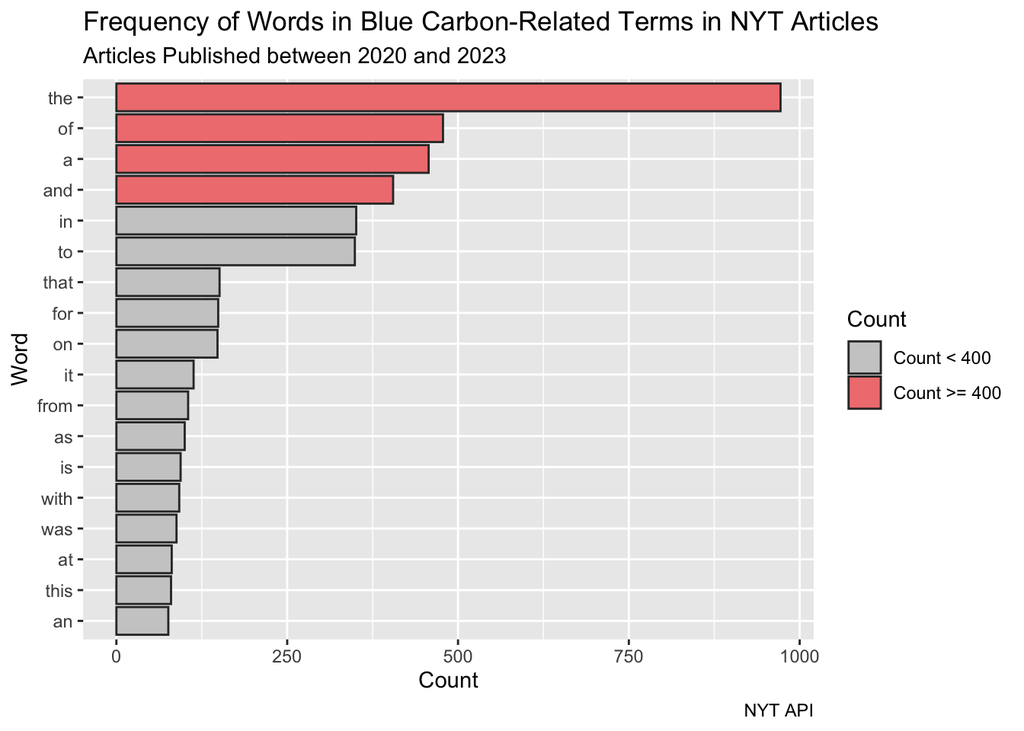

```r
lead_paragraph <- names(blue_carbon_df)[6] # The 6th column for the lead paragraph

# Create new Data Frames with the all the words of the lead paragraph section.
df_paragraph <- blue_carbon_df |>
  unnest_tokens(word, lead_paragraph) |>
  select("word")

# Create a graph with the most common words
df_paragraph %>%
  count(word, sort = T) %>%
  filter(n > 75) %>%
  mutate(word = reorder(word, n)) %>%
  ggplot(aes(x = reorder(word, n), y = n, fill = n >= 400)) +
  geom_bar(stat = "identity", color = "gray20") +
  coord_flip() +
  scale_fill_manual(values = c("gray80", "lightcoral"),
                    labels = c("Count < 400", "Count >= 400"),
                    name = "Count") +
  labs(title= "Frequency of Words in Blue Carbon-Related Terms in NYT Articles",
       subtitle= "Articles Published between 2020 and 2023",
       x = "Word",
       y = "Count",
       caption = "NYT API")
```

As we can see in this graph the most common words are pretty irrelevant. That why we need to do some transformations.

### Transformation #1

Make the first transformation and delete the words that are not helpful

```r
# Using the Data Frame called "stop_words"
data(stop_words)
stop_words
```

```
## # A tibble: 1,149 × 2
##    word        lexicon
##    <chr>       <chr>
##  1 a           SMART
##  2 a's         SMART
##  3 able        SMART
##  4 about       SMART
##  5 above       SMART
##  6 according   SMART
##  7 accordingly SMART
##  8 across      SMART
##  9 actually    SMART
## 10 after       SMART
## # … with 1,139 more rows
```

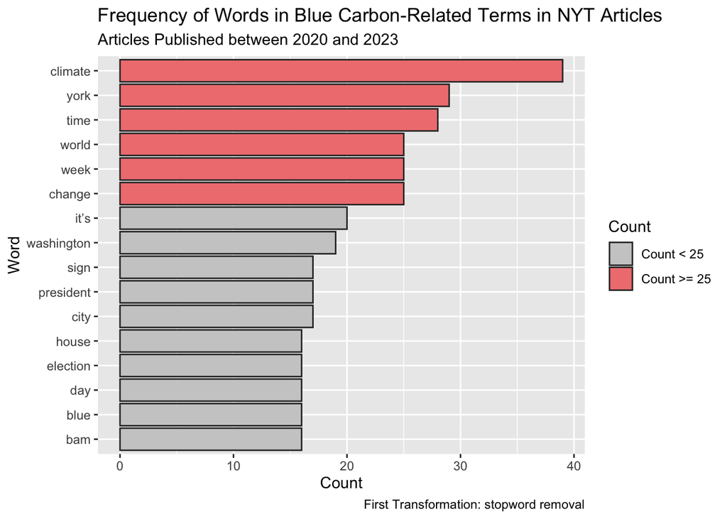

```r
clean_paragraph <- df_paragraph |>
  anti_join(stop_words)
clean_paragraph %>%
  count(word, sort = T) %>%
  filter(n > 15) %>%
  mutate(word = reorder(word, n)) %>%
  ggplot(aes(x = reorder(word, n), y = n, fill = n >= 25)) +
  geom_bar(stat = "identity", color = "gray20") +
  coord_flip() +
  scale_fill_manual(values = c("gray80", "lightcoral"),
                    labels = c("Count < 25", "Count >= 25"),
                    name = "Count") +
  labs(title= "Frequency of Words in Blue Carbon-Related Terms in NYT Articles",
       subtitle= "Articles Published between 2020 and 2023",
       x = "Word",
       y = "Count",
       caption = "First Transformation: stopword removal")
```

Now we have a better list of our top frequent words in blue carbon related articles.

### Transformation #2

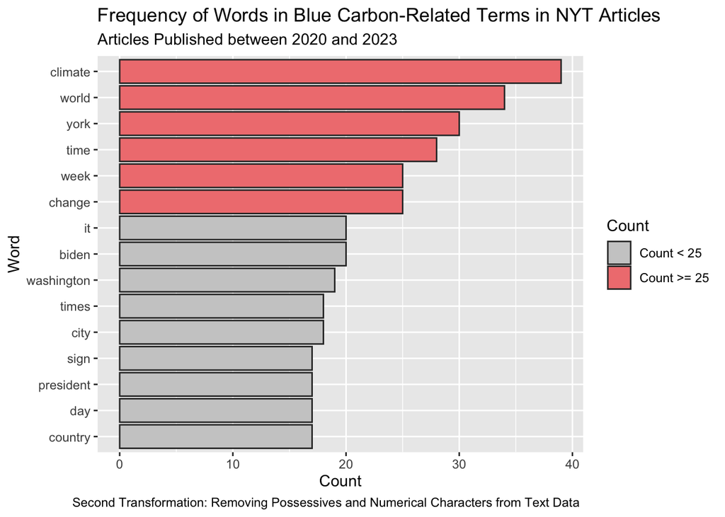

```r
# Clean Words with 's and numbers
clean_paragraph_2 <- clean_paragraph %>%
  mutate(word = gsub("'s", '', word)) %>%
  mutate(word = gsub("´s", '', word)) %>%
   mutate(word = gsub("’s", '', word)) %>%
  mutate(word = str_remove_all(word, "[:digit:]")) %>%
  filter(word != "" & word != "." & word != ",")


# Count the new frequency of each word
clean_paragraph_2 %>%
  count(word, sort = T) %>%
  filter(n > 16) %>%
  mutate(word = reorder(word, n)) %>%
  ggplot(aes(x = reorder(word, n), y = n, fill = n >= 25)) +
  geom_bar(stat = "identity", color = "gray20") +
  coord_flip() +
  scale_fill_manual(values = c("gray80", "lightcoral"),
                    labels = c("Count < 25", "Count >= 25"),
                    name = "Count")  +
  labs(title= "Frequency of Words in Blue Carbon-Related Terms in NYT Articles",
       subtitle= "Articles Published between 2020 and 2023",
       x = "Word",
       y = "Count",
       caption = "Second Transformation: Removing Possessives and Numerical Characters from Text Data ")
```

### Transformation #3

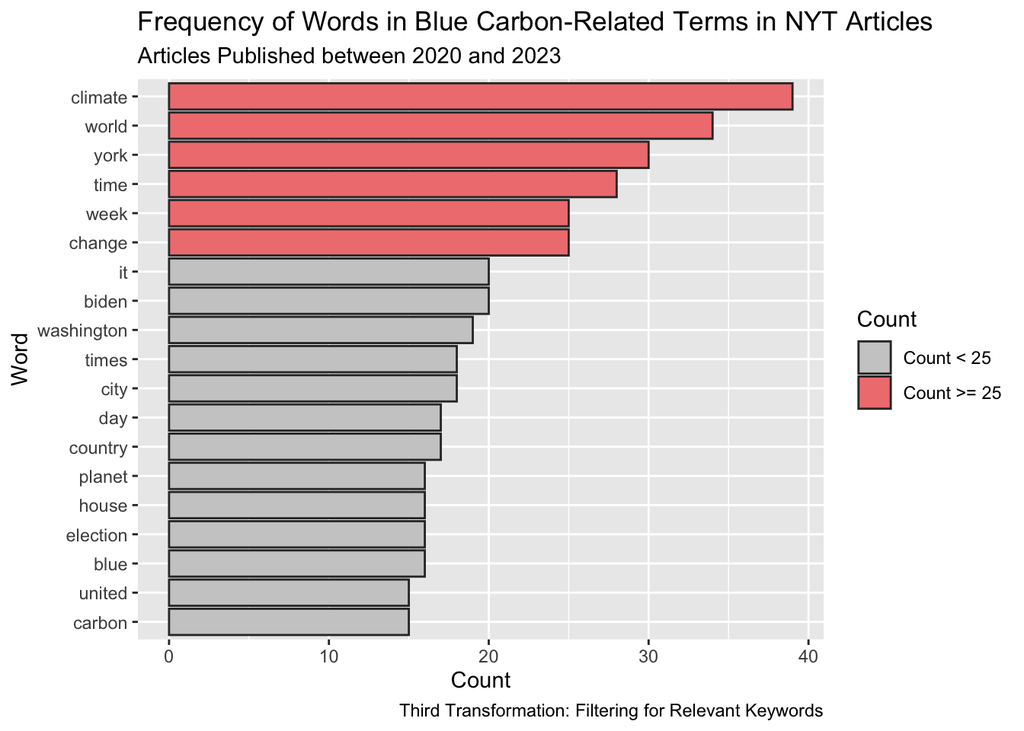

```r
# Extract the list of the keywords per article and create a new data frame so we can inner_join and see what are the key words.
blue_carbon_keywords <- blue_carbon_df %>%
  unnest(response.docs.keywords) |>
  select(value) |>
  unnest_tokens(word, value) |>
  distinct()


clean_paragraph_3 <- semi_join(clean_paragraph_2, blue_carbon_keywords, by = "word")

# Count the new frequency of each word
clean_paragraph_3 %>%
  count(word, sort = T) %>%
  filter(n > 14) %>%
  mutate(word = reorder(word, n)) %>%
  ggplot(aes(x = reorder(word, n), y = n, fill = n >= 25)) +
  geom_bar(stat = "identity", color = "gray20") +
  coord_flip() +
  scale_fill_manual(values = c("gray80", "lightcoral"),
                    labels = c("Count < 25", "Count >= 25"),
                    name = "Count")  +
  labs(title= "Frequency of Words in Blue Carbon-Related Terms in NYT Articles",
       subtitle= "Articles Published between 2020 and 2023",
       x = "Word",
       y = "Count",
       caption = "Third Transformation: Filtering for Relevant Keywords")
```

### 4) Recreate the publications per day and word frequency plots using the headlines variable (response.docs.headline.main). Compare the distributions of word frequencies between the first paragraph and headlines. Do you see any difference? (Here you will have fewer lines, but what are the most frequent words)

```r
head_line <- names(blue_carbon_df)[21]  # The 21 column for the headline

# Creating the df with all words
df_headline <- blue_carbon_df |>
  unnest_tokens(word, head_line) |>
  select("word")

# Cleaning the irrelevant words
clean_headline <- df_headline |>
  anti_join(stop_words) %>% # First transformation "stop_words"
  mutate(word = gsub("'s", '', word)) %>% #second transformation
  mutate(word = gsub("´s", '', word)) %>% #second transformation
   mutate(word = gsub("’s", '', word)) %>% #second transformation
  mutate(word = str_remove_all(word, "[:digit:]")) %>%#second transformation
  filter(word != "" & word != "." & word != ",") |> #second transformation
  semi_join(blue_carbon_keywords, by = "word") |> #third transformation
  semi_join(clean_paragraph_3, by = "word") #third transformation
```

Plot the new graph

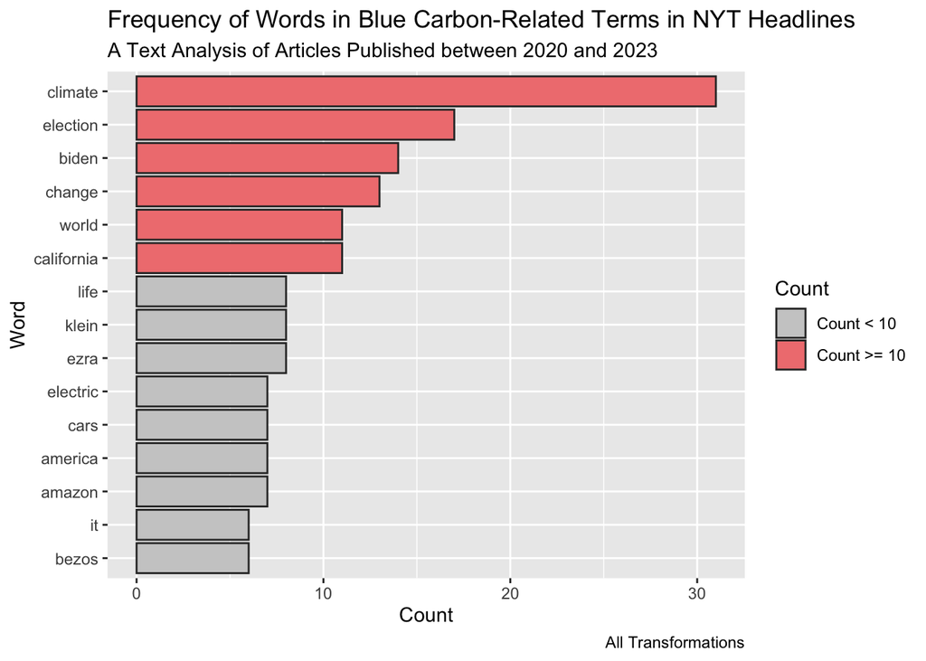

```r
clean_headline %>%
  count(word, sort = T) %>%
  filter(n > 5) %>%
  mutate(word = reorder(word, n)) %>%
  ggplot(aes(x = reorder(word, n), y = n, fill = n >= 10)) +
  geom_bar(stat = "identity", color = "gray20") +
  coord_flip() +
  scale_fill_manual(values = c("gray80", "lightcoral"),
                    labels = c("Count < 10", "Count >= 10"),
                    name = "Count")  +
  labs(title= "Frequency of Words in Blue Carbon-Related Terms in NYT Headlines",
       subtitle= "A Text Analysis of Articles Published between 2020 and 2023",
       x = "Word",
       y = "Count",
       caption = "All Transformations")
```

Now there are interesting words in the top of the list like “election”, “biden”, “california”, and life.

Lets find what are the most common and non common words

```r
#Find the words that are not in common

not_common <- anti_join(clean_paragraph_3,clean_headline) |>
  count(word, sort = TRUE) %>%
  top_n(6)
common <- inner_join(clean_paragraph_3,clean_headline) |>
  count(word, sort = TRUE) %>%
  top_n(5)
library(knitr)
library(kableExtra)
not_common_table <- kable(not_common, caption = "Top 6 words in 'clean_paragraph_3' not present in 'clean_headline'") %>%
  kable_styling("striped")


common_table <- kable(common, caption = "Top 5 common words in 'clean_paragraph_3' and 'clean_headline'") %>%
  kable_styling("striped")

# To display the tables
not_common_table
```

Top 6 words in ‘clean_paragraph_3’ not present in ‘clean_headline’

| word | n |
| --- | --- |
| washington | 19 |
| maps | 14 |
| deep | 10 |
| history | 9 |
| news | 9 |
| party | 9 |

```r
common_table
```

Top 5 common words in ‘clean_paragraph_3’ and ‘clean_headline’

| word | n |
| --- | --- |
| climate | 1209 |
| world | 374 |
| change | 325 |
| biden | 280 |
| election | 272 |